# Homework 7

Emily P. Piché

10/10/2018

A pattern I hypothesized that I would see at my sites is a positive relationship between soil organic matter (%) and the proportion of conifers on a plot (%). After collecting my data this summer, I found that at my 23 sites, the proportion of conifers on each plot explained 25% of the variation in soil organic matter.

Here I will create a fake dataset to explore this hypothesis in R using a normal distribution.

Sample sizes and means of my soil organic matter and conifer data:

```r
# calling up MASS and ggplot2
library(MASS)
library(ggplot2)
library(dplyr)
# reading in my own data from a csv
PL <- read.csv("/Users/emilypiche/Desktop/plotlevel.csv", as.is=TRUE)
#SOM - real soil organic matter data
SOM <- PL$LOI
#RC - real conifer proportion data
RC <- PL$CONIFER_D

# SOM parameters
normPars1 <- fitdistr(SOM,"normal")
normPars1
```

```
##       mean          sd
##   0.33442954   0.19826711
##  (0.04134155) (0.02923289)
```

```r
# conifer parameters
normPars2 <- fitdistr(RC,"normal")
normPars2
```

```
##       mean          sd
##   0.33369785   0.32519837
##  (0.06780855) (0.04794788)
```

Assuming these two groups follow a normal distribution (propotion of conifers in each plot, and soil organic matter content (%)), I simulated the following distributions based on parameters from my actual data. I had 23 sites, the mean proportion of conifers was .33, and the standard deviation was 0.325. I created the fake SOM data from the fake conifer data (rather than generating it on its own) because I wanted to generate data that would show a positive relationship with a simple regression, and did not use the actual parameters from my SOM data (n=23, mean=.33, sd=.20)

```r
fCon <- rnorm(length(RC), normPars2$estimate["mean"], normPars2$estimate["sd"]) # creating fake conifer proportions
e <- rnorm(23, .2, .1) # creating some noise

# OM content is a function of the proportion of conifers on each plot, so simulated SOM is created using a noise factor and the fCon data
fSOM <- 0 + .1*fCon+ e

# putting data into a dataframe
simData <- data.frame(fCon, fSOM)
head(simData)
```

```
##          fCon       fSOM
## 1  0.27055604 0.04153725
## 2  1.12522142 0.26216307
## 3  0.04952986 0.18710881
## 4 -0.13357188 0.12495991
## 5  0.77148950 0.23594828
## 6  0.19557635 0.16465047
```

```r
# summary of a linear model of my generated conifer and SOM data
sum <- summary(lm(simData$fSOM~simData$fCon))
r2<-sum$adj.r.squared
p<-sum$coefficients[7]
# r^2 of the linear model
r2
```

```
## [1] 0.2026375
```

```r
# p value of linear model
p
```

```
## [1] 2.274354e-08
```

Here is figure showing one version of the generated data: (This may or may not show a significant relationship depending on the generated data)

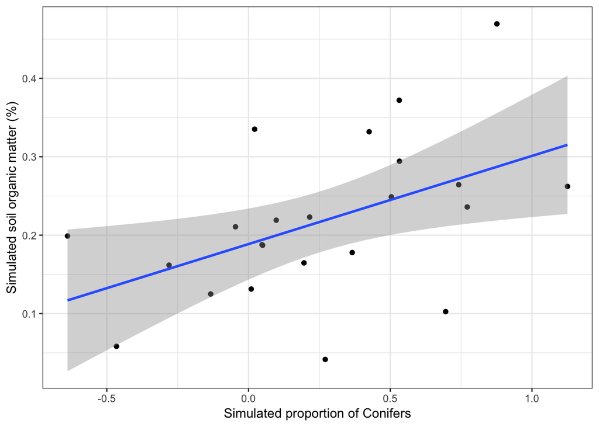

```r
qplot(simData$fCon,simData$fSOM,
      xlab="Simulated proportion of Conifers",
      ylab="Simulated soil organic matter (%)")+ theme_bw() + geom_smooth(method="lm")
```

The r-squared varied quite a bit each time I ran the code, which is likely a factor of the low sample size (.05 - .45). In my real dataset, each site is represented with 3 different cores which are averaged for each site. I think that if I generated the code in this way, it would reduce some of the variation between runs. I also found that I could not constrain the proportion of conifers in the overstory to only include positive numbers because I am doing this exercise using a normal distribution.

```r
e2 <- rnorm(23, .5, .05) # creating less noise with 0.05 sd rather than 0.5, and increasing the mean to .5

# new fake SOM data
fSOM2 <- 0 + .1*fCon+ e2

# new dataframe with fSOM2
simData2 <- data.frame(fCon, fSOM2)
head(simData2)
```

```
##          fCon     fSOM2
## 1  0.27055604 0.4893102
## 2  1.12522142 0.5802258
## 3  0.04952986 0.5257161
## 4 -0.13357188 0.6094945
## 5  0.77148950 0.4673613
## 6  0.19557635 0.5167804
```

```r
# summary of a linear model of my generated conifer and SOM data
sum2 <- summary(lm(simData2$fSOM2~simData$fCon))
R2<-sum2$adj.r.squared
P<-sum2$coefficients[7]
# r^2 of the linear model
R2
```

```
## [1] 0.05162986
```

```r
# p value of linear model
P
```

```
## [1] 1.064652e-20
```

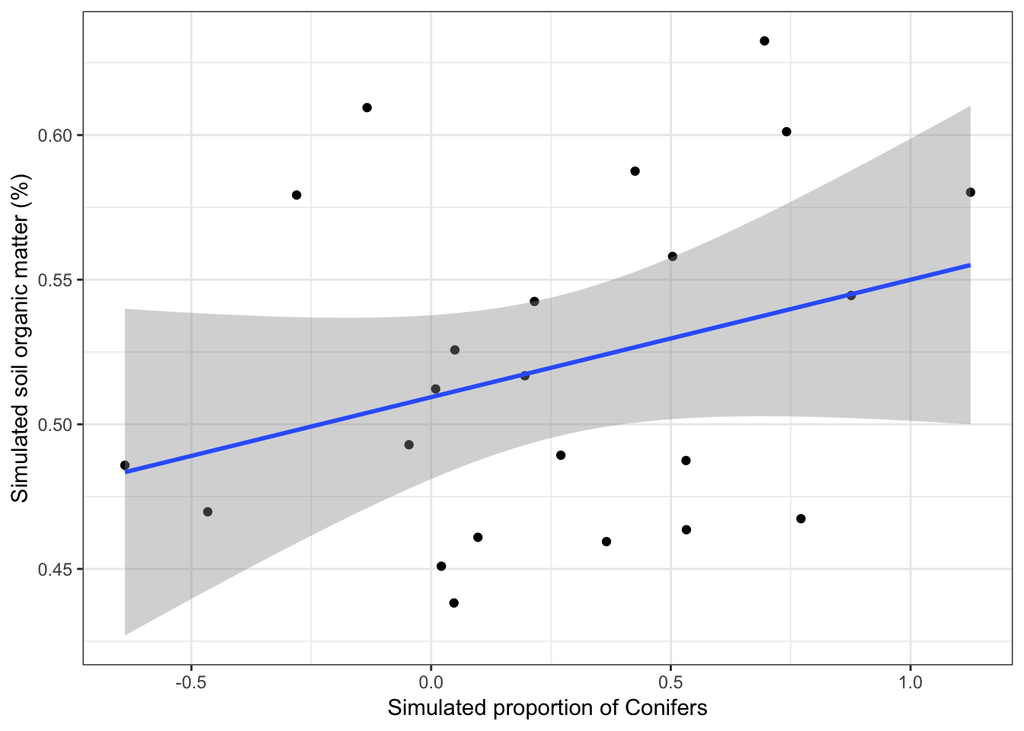

```r
# plot of data with SOM that has less generated noise
qplot(simData2$fCon, simData2$fSOM2,
      xlab="Simulated proportion of Conifers",
      ylab="Simulated soil organic matter (%)")+ theme_bw() + geom_smooth(method="lm")
```